# Climate Change Module

Louis Hedges

```r
library(tidyverse)
```

## Warm-up: Examining CO2 trends in R

- Example from http://climate.nasa.gov/vital-signs/carbon-dioxide/
- Raw data from https://gml.noaa.gov/webdata/ccgg/trends/co2/co2_mm_mlo.txt

In 1958, Dr. Charles David Keeling (1928-2005), a scientist at Scripps Institute of Oceanography, began collecting data on atmospheric CO2 concentration at the Mauna Loa Observatory located in Hawaii. This dataset allowed us to understand the degree to which climate change is human-caused through our burning of fossil fuels and release of CO2 into the atmosphere. Due to his scientific achievements, Dr. Keeling was awarded the National Medal of Science by President George W. Bush in 2002. This is the highest award for lifetime scientific achievement that can be granted in the U.S. Today, you get to analyze this same dataset, except that you have more data than was available to Dr. Keeling and his colleagues because your dataset extends up to the current time.

To read the code, you will use a new function called `read_table`. It is similar to `read_csv` except it looks for spaces between column entries rather than commas (remember that csv stands for comma-separated values). Others include `read_tsv`, which uses tabs to separate entries. You can discover the separation type by putting https://gml.noaa.gov/webdata/ccgg/trends/co2/co2_mm_mlo.txt into your web browser and examining the file. The code also includes an argument for comment, which denotes the character used to define a line in the file as being a comment rather than data or a header. The file also reveals that the column headers are on lines with a comment character, so they won’t be read. You will use the argument `col_names` to define the headers manually. Finally, `NA` values are defined by the numbers -1 and -99, so they need to be defined using the `na` argument (otherwise, they will be read as numeric values).

```r
co2 <-  read_table("https://gml.noaa.gov/webdata/ccgg/trends/co2/co2_mm_mlo.txt",
                  comment="#",
                  col_names = c("year", "month", "decimal_date",
                                "monthly_average",
                                "deseasonalized", "days", "sd_days",
                                "unc_month_mean"),
                  na = c("-1", "-99.99"))
co2
```

```
## # A tibble: 803 × 8
##     year month decimal_date monthly_average deseasonalized  days sd_days
##    <dbl> <dbl>        <dbl>           <dbl>          <dbl> <dbl>   <dbl>
##  1  1958     3        1958.            316.           314.    NA   -9.99
##  2  1958     4        1958.            317.           315.    NA   -9.99
##  3  1958     5        1958.            318.           315.    NA   -9.99
##  4  1958     6        1958.            317.           315.    NA   -9.99
##  5  1958     7        1959.            316.           315.    NA   -9.99
##  6  1958     8        1959.            315.           316.    NA   -9.99
##  7  1958     9        1959.            313.           316.    NA   -9.99
##  8  1958    10        1959.            312.           315.    NA   -9.99
##  9  1958    11        1959.            313.           315.    NA   -9.99
## 10  1958    12        1959.            315.           315.    NA   -9.99
## # ℹ 793 more rows
## # ℹ 1 more variable: unc_month_mean <dbl>
```

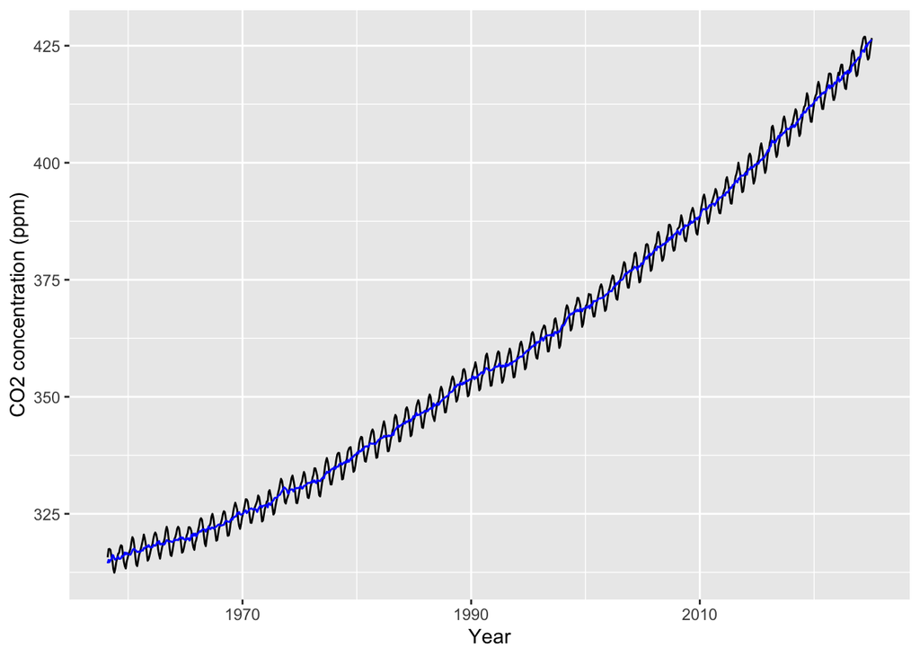

```r
ggplot(co2, aes(x = decimal_date, y = monthly_average)) +
  geom_line() +
  geom_line(aes(y = deseasonalized), color = "blue") +
  labs(x = "Year", y = "CO2 concentration (ppm)")
```

**Question 1:**

Describe the overall trend in the CO2 data.

**Answer 1:** Looking at the data we can see there is clearly a positive correlation. An increase in the years will show there is an increase in CO2 concentration.

**Question 2:**

How does CO2 vary within a year? What month is it at max? Min? What might explain this sub-annual pattern? (you will need to write code and make a plot to answer this question)

**Answer 2:**

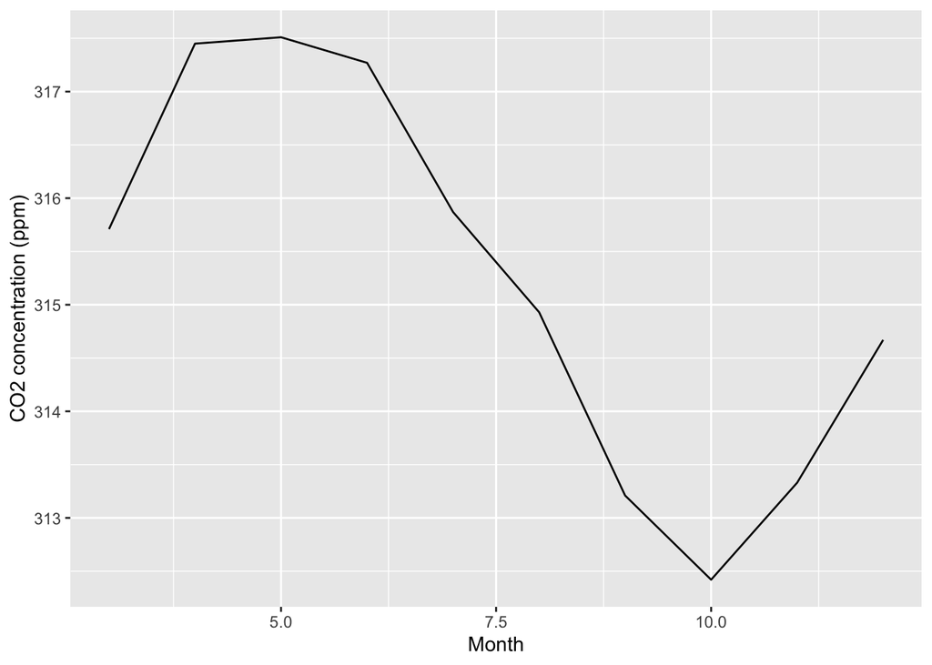

```r
year <- co2 |> filter(year == 1958)
ggplot(year, aes(x = month, y = monthly_average)) +
  geom_line() +
  labs(x = "Month", y = "CO2 concentration (ppm)")
```

We can see that the highest month is the 5th month with a value of 317.5. With the data year being 1958. The sub annual pattern could be due to the weather change in the later parts of the year.

## Global Temperature Data

Current climate change affects many aspects of the environment, with socio-economic consequences. For example, a warmer climate can allow new diseases to be introduced and persist (e.g., West Nile became established in the United States after an unusually warm winter, which allowed the mosquitoes that carry the virus to survive and spread). We are concerned not only with the actual temperature but also with the rate at which it changes. Rapid changes make it more likely that species cannot adapt and will go extinct.

Each of the most recent years has been the warmest on record. In this section, we will analyze global mean temperature data.

Data from: https://climate.nasa.gov/vital-signs/global-temperature/

**Question 3:**

Describe the data set to the best of your ability, given the documentation provided.

- Where is the data from?
- Describe the class of each column and what units it is measured in.
- What is the difference between “global temperature” and “global temperature anomaly”?

**Question 4:**

Construct the necessary R code to import and prepare for plotting the following data set: https://data.giss.nasa.gov/gistemp/graphs/graph_data/Global_Mean_Estimates_based_on_Land_and_Ocean_Data/graph.txt

You’ll need to determine the file’s delimiter and any comments or skips. You will also need to be sure that you have column names. You will not directly use the code above to read the CO2 data, but that code provides helpful tips for reading the data.

**Answer 4:**

```r
Q4_table <-  read_table("https://data.giss.nasa.gov/gistemp/graphs/graph_data/Global_Mean_Estimates_based_on_Land_and_Ocean_Data/graph.txt")
```

**Question 5:**

Plot the trend in global mean temperatures over time. Describe what you see in the plot and how you interpret the patterns you observe.

**Answer 5:**

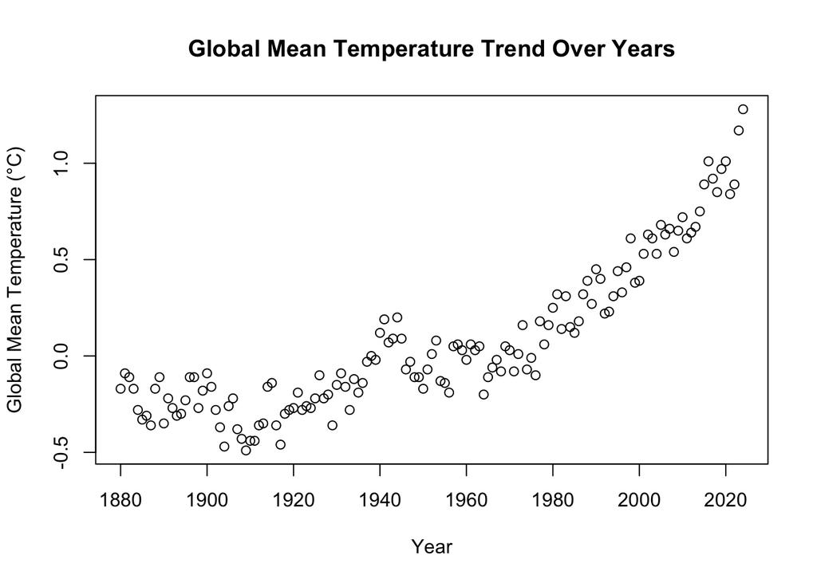

```r
plot(Q4_table$"Land-Ocean", Q4_table$"Temperature",
xlab = "Year", ylab = "Global Mean Temperature (°C)",
     main = "Global Mean Temperature Trend Over Years")
```

```r
# The plot shows a positive correlation starting from the year 1880 all the way to 2020.
```

The [2013 IPCC Report](https://www.ipcc.ch/pdf/assessment-report/ar5/wg1/WG1AR5_SummaryVolume_FINAL.pdf) included a tentative observation of a “much smaller increasing trend” in global mean temperatures since 1998 than was observed previously. This led to much discussion in the media about the existence of a “Pause” or “Hiatus” in global warming rates, as well as much research looking into where the extra heat could have gone. (Examples discussing this question include articles in [The Guardian](http://www.theguardian.com/environment/2015/jun/04/global-warming-hasnt-paused-study-finds), [BBC News](http://www.bbc.com/news/science-environment-28870988), and [Wikipedia](https://en.wikipedia.org/wiki/Global_warming_hiatus)).

You will use rolling averages to help you explore the evidence for a pause. Since you have not been provided instructions for calculating rolling means, the learning objective of this question is to practice finding the solution.

**Question 6:**

Use a search engine (e.g., Google) or a chat LLM to find out how to calculate a rolling average in R. What search term or chat LLM prompt did you use? What website or answer from the chat LLM did you end up using? How much did you need to modify the code from the website or chat LLM to answer the question successfully?

**Answer 6:**

I used ChatGPT to do this research, in doing so it told me to use the zoo package, this would allow me to use the rollmean() function. However a paramter k is needed to give the amount of years.

**Question 7:**

- What is the meaning of “5-year average” vs. “annual average”?
- Create a data frame from the annual temperature anomaly data (from Question 4) with three new columns: 5-year running averages, 10-year running averages, and 20-year running averages.

**Answer 7:**

```r
# The meaning of a 5 year average is: the average calculated over 5 consecutive years. Also it is often updated each year.

# The meaning of an annual average is: the average value calculated for a single year.

#install.packages("zoo")
library(zoo)
Q4_Table_New <- Q4_table
Q4_Table_New$Temperature <- as.numeric(Q4_Table_New$Temperature)
```

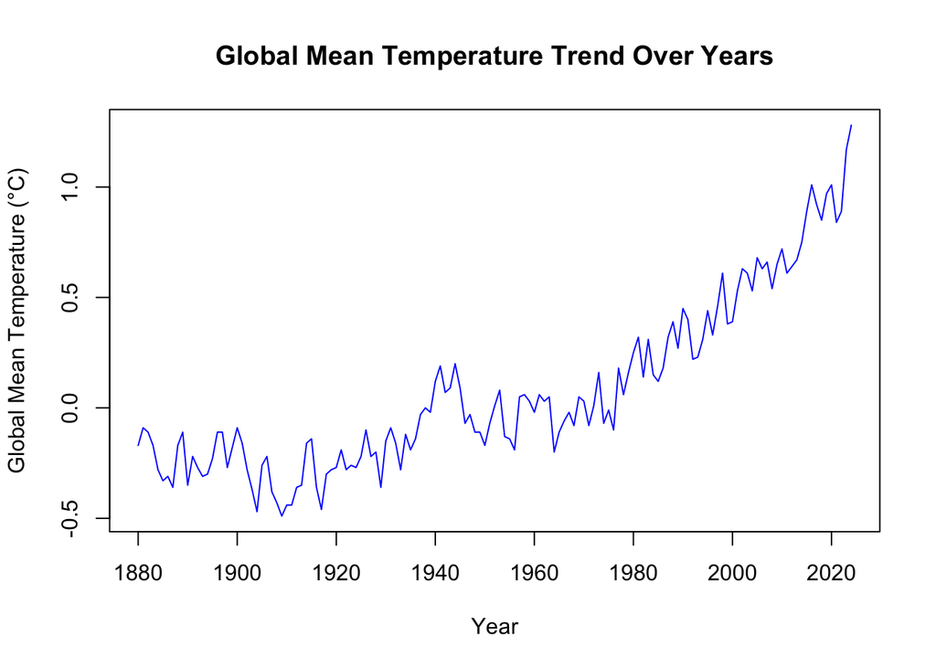

```r
Q4_Table_New <- Q4_Table_New[-c(1:3), ]

Q4_Table_New <- Q4_Table_New[!is.na(Q4_Table_New$Temperature), ]

plot(Q4_Table_New$`Land-Ocean`, Q4_Table_New$Temperature,
     xlab = "Year", ylab = "Global Mean Temperature (°C)",
     main = "Global Mean Temperature Trend Over Years",
     type = "l", col = "blue")
```

```r
Q4_Table_New$Average_5 <- rollmean(Q4_Table_New$Temperature, k = 5, fill = NA, align = "right")
Q4_Table_New$Average_10 <- rollmean(Q4_Table_New$Temperature, k = 10, fill = NA, align = "right")
Q4_Table_New$Average_20 <- rollmean(Q4_Table_New$Temperature, k = 20, fill = NA, align = "right")
```

**Question 8:**

Plot the different averages on the *same plot* and describe what differences you see and why.

**Answer 8:**

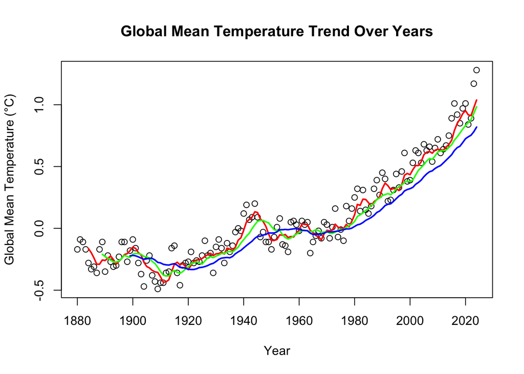

```r
plot(Q4_Table_New$"Land-Ocean", Q4_Table_New$"Temperature",
xlab = "Year", ylab = "Global Mean Temperature (°C)",
     main = "Global Mean Temperature Trend Over Years")

lines(Q4_Table_New$"Land-Ocean", Q4_Table_New$Average_5, col = "Red", lwd = 2)
lines(Q4_Table_New$"Land-Ocean", Q4_Table_New$Average_10, col = "Green", lwd = 2)
lines(Q4_Table_New$"Land-Ocean", Q4_Table_New$Average_20, col = "Blue", lwd = 2)
```

```r
# All the lines are extremely similar to each other and follow the positive correlation of the averages throughout. The biggest difference I noticed is with the blue line (Which is 20 years average), this shows a slightly more shallow line underneath the others and underneath the averages.
```

**Question 9:**

By examining the data here, what evidence do you find or not find for such a pause?

**Answer 9:**

Looking at the table, in my opinion I don’t see a “pause” within the temperature rising. It has been dramatically increasing more since the year 1980. And with the provided data I don’t expect it to slow down or for a pause to happen in the upcoming years.

## Longer term trends in CO2 Records

When analyzing Earth’s climate, it is important to remember that Earth is 4.54 billion years old. Our analyses so far have only looked at recent history. How can we compare the recent data to prehistoric times? Are the current rates of change similar or different from those the earth has experienced in the past? To explore this, we can use data from ice cores drilled at the poles.

Hundreds of ice cores have been extracted from polar ice because they contain valuable data on atmospheric chemistry over pre-historic times. These valuable data exist in tiny air bubbles trapped in the ice. These air bubbles contain the same gases in the same ratios as the atmosphere at the time when the ice formed. The data you will analyze today are from ice cores extracted from the Vostok research station in Antarctica. As you have probably assumed, the depth of the ice core is related to how old the ice is; deep ice is older. There are two other variables that you will be analyzing from the ice cores. You will analyze CO2 concentration, which has been measured from air bubbles trapped in the ice. We can use these data to see what rates of change were like during this pre-historic period, during which human activity was minimal.

[Ice core data](https://data.ess-dive.lbl.gov/view/doi%3A10.3334%2FCDIAC%2FATG.009):

Vostok Core, back to 400,000 years before the present day

- Description of data set: https://data.ess-dive.lbl.gov/view/doi%3A10.3334%2FCDIAC%2FATG.009
- data: https://data.ess-dive.lbl.gov/catalog/d1/mn/v2/object/ess-dive-457358fdc81d3a5-20180726T203952542

You will use this code to download the data to your computer.

```r
download.file("https://data.ess-dive.lbl.gov/catalog/d1/mn/v2/object/ess-dive-457358fdc81d3a5-20180726T203952542",
              destfile = "vostok.icecore.co2")
```

You can click on the file in your Files pane to view it before reading into R.

**Question 10:**

The broad question is: how do recent atmospheric CO2 levels compare to historical levels?

Your answer to Question 10 is going to be a mix of code chunks and text that you put below in “Answer 10:”

- Describe the data set: what are the columns and units? Where do the numbers come from?
- What is the temporal resolution of the data?
- Read in and prepare data for analysis.
- Reverse the ordering to create a chronological record so that each measurement is associated with calender year.
- Plot data.
- Combine this time series with the Mauna Loa data (the Warm-up exercise in this assignment). You will use “bind_rows()”.
- Plot the combined data. (the most recent time period must be on the right side of the plot).
- Describe your conclusions to the question “How do recent atmospheric CO2 levels compare to historical levels?” using your plot as supporting evidence.

**Answer 10:**

The data set shows 4 columns, Depth(M), Age of the ice (yr BP), mean age of the air (yr BP), CO2 concentration (PPMV). The data is from January 2003.

```r
Q10_Table <- read_table("https://data.ess-dive.lbl.gov/catalog/d1/mn/v2/object/ess-dive-457358fdc81d3a5-20180726T203952542", skip = 1,
                          col_names = c("Depth M", "Age of the Ice Yr BP", "Mean age of the air yr BP", "CO2 Concentration PPMV"), comment = "#")
Q10_Table <- Q10_Table %>%
  mutate(across(everything(), as.numeric))
Q10_Table <- Q10_Table[complete.cases(Q10_Table), ]

glimpse(Q10_Table)
```

```
## Rows: 363
## Columns: 4
## $ `Depth M`                   <dbl> 149.1, 173.1, 177.4, 228.6, 250.3, 266.0, …
## $ `Age of the Ice Yr BP`      <dbl> 5679, 6828, 7043, 9523, 10579, 11334, 1344…
## $ `Mean age of the air yr BP` <dbl> 2342, 3634, 3833, 6220, 7327, 8113, 10123,…
## $ `CO2 Concentration PPMV`    <dbl> 284.7, 272.8, 268.1, 262.2, 254.6, 259.6, …
```

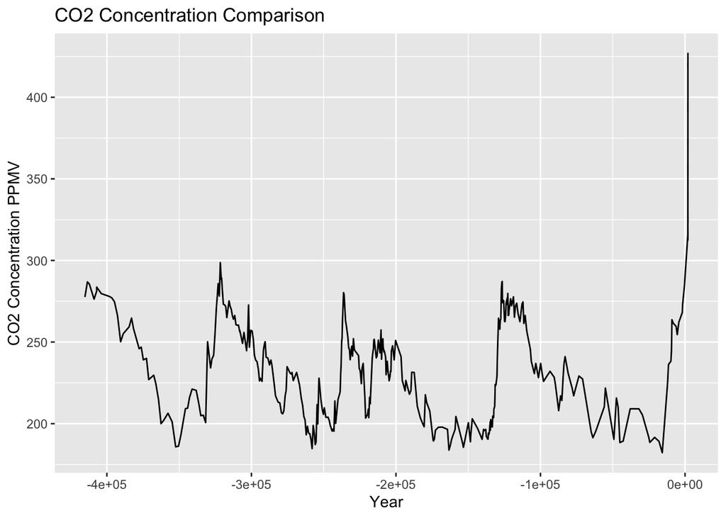

```r
Q10_Table <- Q10_Table %>%
  mutate(year = 1950 - `Mean age of the air yr BP`)

Q10_Table <- Q10_Table %>%
  arrange(year)

Mauna_Loa_Data <- co2


combined_plot <- bind_rows(
  Q10_Table %>% select(year, `CO2 Concentration PPMV`),
  Mauna_Loa_Data %>% rename(`CO2 Concentration PPMV` = monthly_average) %>% select(year, `CO2 Concentration PPMV`)
)

ggplot(combined_plot, aes(x = year, y = `CO2 Concentration PPMV`)) +
  geom_line() +
  labs(title = "CO2 Concentration Comparison",
       x = "Year",
       y = "CO2 Concentration PPMV")
```

```r
# Using my plot and using my new combined data table. I can see that recent CO2 levels are significantly higher than historic levels. Looking at the plot we can see that historic levels of CO2 ranged between 180 - 300 PPMV during certain periods. However in recent times there has been a significant increase which shows the levels of PPMV increase to roughly 420 PPMV.
```

# Render and committing

Remember to Render your document as HTML and comment+push to GitHub your code and rendered HTML that was created when you knitted the document. Your GitHub repository should have multiple commits with informative commit messages.

# Attribution

Include citation of any AI-generated assistance or discussion with classmates (per policy in syllabus). Proper documentation of AI-generated assistance includes the prompt, the source (e.g., ChatGPT), and the significant parts of the response. Proper documentation of discussion with classmates include listing their names and the components discussed.

### Lines 214 - 219 I used chatgpt to help debug the dataset and remove the beginning points of data that were chr data points rather than numeric. Also the columns were not aligned and when I used the read_table function the columns were shown vertically rather than horizontally which R would not read.

### Prompt : “Q10_Table <- read_table(…) is giving me an error. How can I fix this specifc error to do with column specification and clean the data properly?”

### Source : ChatGPT by OpenAI

### Response Used : Lines 214-219

# Q10_Table <- Q10_Table %>%

# mutate(across(everything(), as.numeric))

# Q10_Table <- Q10_Table[complete.cases(Q10_Table), ]

# glimpse(Q10_Table)

# Date: February 18th, 2025